# ハロプログループの最小・最大年齢の推移をバーチャートレースで可視化

[@anemptyarchive](https://www.anarchive-beta.com/)

2022-06-21 11:57:44

・編集履歴

- 2022/06/21：初稿

# 最小・最大年齢の推移の可視化

ハロー！プロジェクトのグループ・ユニットの最小年齢または最大年齢の推移をバーチャートレースで可視化します。

次のパッケージを利用します。

```r
# 利用パッケージ
library(tidyverse)
library(lubridate)
library(gganimate)
```

この記事では、基本的に`パッケージ名::関数名()`の記法を使うので、パッケージを読み込む必要はありません。  
ただし、パイプ演算子`%>%`を使うため`magrittr`と、作図コードがごちゃごちゃしないようにパッケージ名を省略するため`ggplot2`は読み込む必要があります。

## データの読込

「HP_DB」のデータを利用します。GitHub上のcsvデータをRから読み込めたらよかったのですがやり方が分からなかったので、ダウンロードしてローカルフォルダに保存しておきます。

保存先のフォルダパスを指定します。

```r
# フォルダパスを指定
dir_path <- "data/HP_DB-main/"
```

ファイルの読み込み時にファイル名を結合する(ファイルパスにする)ので、末尾を`/`にしておきます。

メンバーの情報を読み込みます。

```r
# メンバー一覧を読み込み
member_df <- readr::read_csv(
  file = paste0(dir_path, "member.csv"),
  col_types = readr::cols(
    memberID = "i",
    memberName = "c",
    HPjoinDate = readr::col_date(format = "%Y/%m/%d"),
    debutDate = readr::col_date(format = "%Y/%m/%d"),
    HPgradDate = readr::col_date(format = "%Y/%m/%d"),
    memberKana = "c",
    birthDate = readr::col_date(format = "%Y/%m/%d")
  )
) |>
  dplyr::arrange(memberID) # 昇順に並べ替え
member_df
```

```
## # A tibble: 273 × 7
##    memberID memberName HPjoinDate debutDate  HPgradDate memberKana    birthDate
##       <int> <chr>      <date>     <date>     <date>     <chr>         <date>
##  1        1 中澤裕子   1997-09-14 1998-01-28 2009-03-31 なかざわゆう… 1973-06-19
##  2        2 石黒彩     1997-09-14 1998-01-28 2000-01-07 いしぐろあや  1978-05-12
##  3        3 飯田圭織   1997-09-14 1998-01-28 2009-03-31 いいだかおり  1981-08-08
##  4        4 安倍なつみ 1997-09-14 1998-01-28 2009-03-31 あべなつみ    1981-08-10
##  5        5 福田明日香 1997-09-14 1998-01-28 1999-04-18 ふくだあすか  1984-12-17
##  6        6 平家みちよ 1997-11-05 1997-11-05 2002-11-07 へいけみちよ  1979-04-06
##  7        7 保田圭     1998-05-03 1998-05-03 2009-03-31 やすだけい    1980-12-06
##  8        8 矢口真里   1998-05-03 1998-05-03 2005-04-14 やぐちまり    1983-01-20
##  9        9 市井紗耶香 1998-05-03 1998-05-03 2000-05-21 いちいさやか  1983-12-31
## 10       10 信田美帆   1999-02-21 1999-04-21 2000-10-09 しのだみほ    1972-05-18
## # … with 263 more rows
```

```r
# 重複データを確認
member_df |>
  dplyr::filter(memberID %in% c(19, 41))
```

```
## # A tibble: 4 × 7
##   memberID memberName HPjoinDate debutDate  HPgradDate memberKana   birthDate
##      <int> <chr>      <date>     <date>     <date>     <chr>        <date>
## 1       19 戸田鈴音   1999-04-27 NA         2000-04-30 とだりんね   1981-02-06
## 2       19 りんね     2000-05-01 2001-04-18 2002-10-13 りんね       1981-02-06
## 3       41 紺野あさ美 2001-08-26 2001-08-26 2006-07-23 こんのあさみ 1987-05-07
## 4       41 紺野あさ美 2007-07-15 2007-07-15 2009-03-31 こんのあさみ 1987-05-07
```

「戸田鈴音」さんは改名によるもので、「紺野あさ美」さんはモーニング娘。卒業の後にハロプロ復帰したためです。  
また、誕生日が欠損しているデータがあります。

```r
# 欠損データを確認
member_df |>
  dplyr::filter(is.na(birthDate))
```

```
## # A tibble: 2 × 7
##   memberID memberName HPjoinDate debutDate HPgradDate memberKana     birthDate
##      <int> <chr>      <date>     <date>    <date>     <chr>          <date>
## 1       21 小林梓     1999-04-27 NA        1999-08-23 こばやしあずさ NA
## 2       98 大柳麻帆   2004-08-10 NA        2005-07-01 おおやなぎまほ NA
```

誕生日が公表されていないようです。

グループの情報を読み込みます。

```r
# グループ一覧を読み込み
group_df <- readr::read_csv(
  file = paste0(dir_path, "group.csv"),
  col_types = readr::cols(
    groupID = "i",
    groupName = "c",
    formDate = readr::col_date(format = "%Y/%m/%d"),
    dissolveDate = readr::col_date(format = "%Y/%m/%d"),
    isUnit = "l"
  )
) |>
  dplyr::arrange(groupID, formDate) # 昇順に並べ替え
group_df
```

```
## # A tibble: 60 × 5
##    groupID groupName          formDate   dissolveDate isUnit
##      <int> <chr>              <date>     <date>       <lgl>
##  1       1 モーニング娘。     1997-09-14 2013-12-31   FALSE
##  2       1 モーニング娘。 '14 2014-01-01 2014-12-31   FALSE
##  3       1 モーニング娘。 '15 2015-01-01 2015-12-31   FALSE
##  4       1 モーニング娘。 '16 2016-01-01 2016-12-31   FALSE
##  5       1 モーニング娘。 '17 2017-01-01 2017-12-31   FALSE
##  6       1 モーニング娘。 '18 2018-01-01 2018-12-31   FALSE
##  7       1 モーニング娘。 '19 2019-01-01 2019-12-31   FALSE
##  8       1 モーニング娘。 '20 2020-01-01 2020-12-31   FALSE
##  9       1 モーニング娘。 '21 2021-01-01 2021-12-31   FALSE
## 10       1 モーニング娘。 '22 2022-01-01 NA           FALSE
## # … with 50 more rows
```

group.csvは、グループID・グループ名・結成日・解散日・ユニットかどうかの5列のcsvファイルです。改名グループであれば結成日・解散日は改名日を表し、現在活動中であれば解散日が欠損値になります。  
例えば、「モーニング娘。とモーニング娘。’14」「スマイレージとアンジュルム」「カントリー娘。とカントリー・ガールズ」は同一のグループとして共通のグループIDを持ちます。よって、`groupID`列の値は重複し、`groupName`列の値(文字列)は重複しません。

メンバーの加入日・卒業日の情報を読み込みます。

```r
# 加入・卒業日一覧を読み込み
join_df <- readr::read_csv(
  file = paste0(dir_path, "join.csv"),
  col_types = readr::cols(
    memberID = "i",
    groupID = "i",
    joinDate = readr::col_date(format = "%Y/%m/%d"),
    gradDate = readr::col_date(format = "%Y/%m/%d")
  )
) |>
  dplyr::arrange(joinDate, memberID, groupID) # 昇順に並べ替え
join_df
```

```
## # A tibble: 514 × 4
##    memberID groupID joinDate   gradDate
##       <int>   <int> <date>     <date>
##  1        1       1 1997-09-14 2001-04-15
##  2        2       1 1997-09-14 2000-01-07
##  3        3       1 1997-09-14 2005-01-30
##  4        4       1 1997-09-14 2004-01-25
##  5        5       1 1997-09-14 1999-04-18
##  6        7       1 1998-05-03 2003-05-05
##  7        8       1 1998-05-03 2005-04-14
##  8        9       1 1998-05-03 2000-05-21
##  9        2       2 1998-10-18 2000-01-07
## 10        3       2 1998-10-18 2002-09-23
## # … with 504 more rows
```

join.csvは、メンバーID・グループID・加入日・卒業日の4列のcsvファイルです。現在活動中であれば卒業日が欠損値になります。  
member.cscのメンバーID、group.csvのグループIDと対応しています。

このデータを利用して、各グループ・ユニットの最小・最大年齢を集計します。

## 期間の指定

アニメーションとしてグラフ化する(最小・最大年齢を集計する)期間を指定します。

```r
# 期間を指定
date_from <- "1997-09-01"
date_to   <- "2022-06-20"
#date_to   <- lubridate::today()
```

開始日を`date_from`、終了日を`date_to`として期間を指定します。文字列で`yyyy-mm-dd`や`yyyy/mm/dd`、`yyyymmdd`などと指定できます。現在の日付を使う場合は、`today()`で設定します。

集計に利用する期間内の全ての月を持つベクトルを作成します。

```r
# 月ベクトルを作成
date_vec <- seq(
  from = date_from |>
    lubridate::as_date() |>
    lubridate::floor_date(unit = "mon"),
  to = date_to |>
    lubridate::as_date() |>
    lubridate::floor_date(unit = "mon"),
  by = "mon"
)
length(date_vec) # フレーム数
```

```
## [1] 298
```

`seq()`で、第1引数`from`から第2引数`to`までのベクトルを作成します。第3引数`by`に`"mon"`を指定すると、1か月間隔の値を作成します。  
文字列型で指定した日付を、`as_date()`でDate型に変換し、さらに`floor_date()`の`unit`引数に`"mon"`を指定して月初の日付にして(日にちを切り捨てて)使います。

アニメーションでは、1月ずつフレーム(グラフ)を切り替えるので、`date_vec`の要素数がフレーム数になります。

## 演出用の処理

集計を行う前に、アニメーションの演出用のデータフレームを作成します。

### 改名グループの対応データ

各フレーム(各グラフ・各月)に応じてグループ名のラベルを変更するために、月とグループ名の対応データを作成します。

「期間内の全ての月」と「各月におけるグループ名」のデータフレームを作成します。

```r
# 月・グループID・グループ名の対応表を作成
group_name_df <- group_df |>
  dplyr::mutate(
    formDate = formDate |>
      lubridate::floor_date(unit = "mon"),
    dissolveDate = dissolveDate %>%
      dplyr::if_else(
        condition = is.na(.),
        true = lubridate::today(),
        false = dissolveDate
      ) |> # 現在活動中なら現在の日付
      lubridate::floor_date(unit = "mon"),
    n = lubridate::interval(start = formDate, end = dissolveDate) |>
      lubridate::time_length(unit = "mon") + 1
  ) |> # 月単位に切り捨てて月数をカウント
  tidyr::uncount(n) |> # 月数に応じて行を複製
  dplyr::group_by(groupName) |> # 行番号用にグループ化
  dplyr::mutate(idx = dplyr::row_number()) |> # 行番号を割り当て
  dplyr::group_by(groupName, idx) |> # 1か月刻みの値の作成用にグループ化
  dplyr::mutate(date = seq(from = formDate, to = dissolveDate, by = "mon")[idx]) |> # 複製した行を1か月刻みの値に変更
  dplyr::group_by(date, groupID) |> # 重複の除去用にグループ化
  dplyr::slice_max(formDate) |> # 重複する場合は新しい方を抽出
  dplyr::ungroup() |> # グループ化を解除
  dplyr::select(date, groupID, groupName, formDate, dissolveDate) |> # 利用する列を選択
  dplyr::arrange(date, groupID) # 昇順に並べ替え
group_name_df
```

```
## # A tibble: 3,251 × 5
##    date       groupID groupName      formDate   dissolveDate
##    <date>       <int> <chr>          <date>     <date>
##  1 1997-09-01       1 モーニング娘。 1997-09-01 2013-12-01
##  2 1997-10-01       1 モーニング娘。 1997-09-01 2013-12-01
##  3 1997-11-01       1 モーニング娘。 1997-09-01 2013-12-01
##  4 1997-12-01       1 モーニング娘。 1997-09-01 2013-12-01
##  5 1998-01-01       1 モーニング娘。 1997-09-01 2013-12-01
##  6 1998-02-01       1 モーニング娘。 1997-09-01 2013-12-01
##  7 1998-03-01       1 モーニング娘。 1997-09-01 2013-12-01
##  8 1998-04-01       1 モーニング娘。 1997-09-01 2013-12-01
##  9 1998-05-01       1 モーニング娘。 1997-09-01 2013-12-01
## 10 1998-06-01       1 モーニング娘。 1997-09-01 2013-12-01
## # … with 3,241 more rows
```

`group_df`は、グループ名`groupName`と結成日(改名日)`formDate`・解散日(次の改名日)`dissolveDate`の情報を持ちます。この値を使って、グループ名ごとに、改名・結成月から次の改名・解散月(または現在の月)までの全ての月を作成します。

`formDate, dissolveDate`列を`floor_date()`で結成月と解散月にします。ただし、現在活動中のグループであれば解散日が`NA`なので、`if_else()`と`is.na()`を使って、`today()`で現在の日付に変更します。  
結成月から解散月までの月数を、`interval()`と`time_length()`を使って求めて、`n`列とします。`解散月 - 結成月`が求まるので`+ 1`します。  
グループ名(行)ごとに、`uncount()`で`n`列の値と同じ行数に複製します。  
ここまでで、グループ名ごとに、その名前だった月数に応じてデータが複製されました。続いて、1か月間隔の値を設定します。

複製した行に`row_number()`で行番号を割り当てて、`idx`列とします。  
結成月から解散月までの月ベクトルを`seq()`で作成して、行番号に対応する要素を取り出して、`date`列とします。  
改名日が月の途中だと月(`date`列の値)が重複するので、`slice_max()`で新しい方のデータ(行)を抽出します。

### 結成前月と解散月のデータ

続いて、バーの変化を強調するために、結成1か月前と解散月のデータ(メンバー数が0のデータ)を作成します。

グループごとの「結成1か月前」と「解散月」のデータフレームを作成します。

```r
# 結成前月・解散月のデータを作成
member_0_df <- group_df |>
  dplyr::group_by(groupID) |> # 日付の再設定用にグループ化
  dplyr::mutate(dissolveDate = dplyr::lead(dissolveDate, n = max(dplyr::n())-1)) |> # 最後の行を1行目にズラす
  dplyr::slice_head(n = 1) |> # 1行目を抽出
  dplyr::ungroup() |> # グループ化を解除
  dplyr::mutate(
    formDate = formDate |>
      lubridate::rollback() |> # 結成1か月前に変更
      lubridate::floor_date(unit = "mon"),
    dissolveDate = dissolveDate |>
      lubridate::floor_date(unit = "mon")
  ) |> # 月単位に切り捨て
  tidyr::pivot_longer(
    cols = c(formDate, dissolveDate),
    names_to = "date_type",
    values_to = "date"
  ) |> # 結成前月・解散月を同じ列に変形
  dplyr::select(date, groupID) |> # 利用する列を選択
  dplyr::filter(!is.na(date)) |> # 現在活動中のグループの解散月を除去
  tibble::add_column(
    groupName = " ",
    age = 0
  ) |> # メンバー数(0人)を追加
  dplyr::filter(date > min(date_vec), date < max(date_vec)) |> # 指定した期間内のデータを抽出
  dplyr::arrange(date, groupID) # 昇順に並び替え
member_0_df
```

```
## # A tibble: 76 × 4
##    date       groupID groupName   age
##    <date>       <int> <chr>     <dbl>
##  1 1998-09-01       2 " "           0
##  2 1999-01-01       3 " "           0
##  3 1999-02-01       4 " "           0
##  4 1999-03-01       5 " "           0
##  5 1999-07-01       7 " "           0
##  6 1999-09-01       6 " "           0
##  7 2000-05-01       8 " "           0
##  8 2000-06-01       9 " "           0
##  9 2000-10-01       3 " "           0
## 10 2001-12-01       9 " "           0
## # … with 66 more rows
```

`group_df`の`formDate, dissolveDate`列は、改名したグループだと、最初の行は「結成日・改名日」、途中の行は「改名日・改名日」、最後の行は「改名日・解散日」になります。そこで、グループごとに、`formDate`列の最初の値と`dissolveDate`列の最後の値を取り出して、「結成日・解散日」にします。

`dissolveDate`列の最後の行の値が最初の行に来るように、`lead()`で要素をズラします。ズラす行数の引数`n`に、(各グループの)`データ(行)数 - 1`の値を指定します。行数は`n()`で得られますが行数分の値が返ってくるので、`max()`で1つの値にして使います(一発で行数をスカラで返す関数を使いたい)。  
必要な値を最初の行にまとめられたので、`slice_head()`で最初の行のみ取り出します。  
ここまでで、グループごとに、結成日と解散日をまとめた行が得られました。続いて、次で作成する集計データと対応するようにデータフレームを整形します。

結成日と解散日を`floor_date()`で月初の値にします。その際に、`rollback()`で結成月の1か月前にします。  
`pivot_longer()`で結成前月と解散月の列をまとめて、`date`列とします。その際に、結成か解散かを表す列を`date_type`列としますが、この列は使いません。  
現在活動中のグループの解散月は`NA`なので、`is.na()`を使って取り除きます。  
結成前と解散後はメンバー数が0なので、結合時(集計データ)の列と対応するように値(データ)を設定します。グループ名については、作図時に`"NA"`と表示されないように(空白にするために)半角スペースにしておきます。

演出用の2つのデータフレームを用意できました。次の集計処理に利用します。

## 最小・最大年齢の集計と順位付け

年齢の最小値または最大値を集計してランキングを付けます。

受け皿となるデータフレームの作成用にサイズを取得します。

```r
# サイズを取得
group_size  <- max(group_df[["groupID"]])
member_size <- max(member_df[["memberID"]])
```

グループ数・メンバー数を取得します。

各月における「最小年齢または最大年齢」と「順位」のデータフレームを作成します。

```r
# 最小年齢or最大年齢を集計
rank_df <- tidyr::expand_grid(
  date = date_vec,
  groupID = 1:group_size,
  memberID = 1:member_size
) |> # 全ての組み合わせを作成
  dplyr::left_join(group_name_df, by = c("date", "groupID")) |> # グループ情報を結合
  dplyr::filter(date >= formDate, date <= dissolveDate) |> # 活動中のグループを抽出
  dplyr::select(!c(formDate, dissolveDate)) |> # 不要な列を削除
  dplyr::left_join(
    join_df |>
      dplyr::mutate(
        joinDate = lubridate::floor_date(joinDate, unit = "mon"),
        gradDate = lubridate::floor_date(gradDate, unit = "mon")
      ), # 月単位に切り捨て
    by = c("groupID", "memberID")
  ) |> # 所属メンバー情報を結合
  dplyr::filter(date >= joinDate, date < gradDate | is.na(gradDate)) |> # 活動中のメンバーを抽出
  dplyr::select(!c(joinDate, gradDate)) |> # 不要な列を削除
  dplyr::left_join(
    member_df |>
      dplyr::distinct(memberID, .keep_all = TRUE), # 重複を除去
    by = "memberID"
  ) |> # メンバー情報を結合
  dplyr::select(date, groupID, groupName, memberID, memberName, birthDate) |> # 利用する列を選択
  dplyr::mutate(
    age = lubridate::interval(start = birthDate, end = date) |>
      lubridate::time_length(unit = "year") |>
      floor()
  ) |> # メンバーの年齢を計算
  dplyr::group_by(date, groupID) |> # 最小・最大年齢の抽出用にグループ化
  #dplyr::slice_min(age, n = 1, with_ties = FALSE) |> # グループの最小年齢を抽出
  dplyr::slice_max(age, n = 1, with_ties = FALSE) |> # グループの最大年齢を抽出
  dplyr::select(!c(memberID, memberName, birthDate)) |> # 不要な列を削除
  dplyr::bind_rows(member_0_df) |> # 結成前月・解散月を追加
  dplyr::arrange(date, age, groupID) |> # 順位付け用に並べ替え
  dplyr::group_by(date) |> # 順位付け用にグループ化
  dplyr::mutate(
    groupID = factor(groupID),
    ranking = dplyr::row_number(-age),
  ) |> # 順位を追加
  dplyr::ungroup() |> # グループ化を解除
  dplyr::select(date, groupID, groupName, age, ranking) |> # 利用する列を選択
  dplyr::arrange(date, ranking) # 昇順に並べ替え
rank_df
```

```
## # A tibble: 3,219 × 5
##    date       groupID groupName        age ranking
##    <date>     <fct>   <chr>          <dbl>   <int>
##  1 1997-09-01 1       モーニング娘。    24       1
##  2 1997-10-01 1       モーニング娘。    24       1
##  3 1997-11-01 1       モーニング娘。    24       1
##  4 1997-12-01 1       モーニング娘。    24       1
##  5 1998-01-01 1       モーニング娘。    24       1
##  6 1998-02-01 1       モーニング娘。    24       1
##  7 1998-03-01 1       モーニング娘。    24       1
##  8 1998-04-01 1       モーニング娘。    24       1
##  9 1998-05-01 1       モーニング娘。    24       1
## 10 1998-06-01 1       モーニング娘。    24       1
## # … with 3,209 more rows
```

まずは、データの受け皿となる、月・グループID・メンバーIDの全ての組み合わせを持つデータフレームを作成します。  
次に、各グループの(改名に対応した)名前と、各メンバーの加入・卒業日の情報を結合して、不要な行(組み合わせ)を削除します。  
続いて、各メンバーの誕生日の情報を結合して、各メンバーの年齢を計算し、各グループの年齢の最小値を`slice_min()`または最大値を`slice_max()`で取り出します。最小・最大年齢はコメントアウトで切り替えます。  
最後に、各グループの最小・最大年齢に応じて順位付けして、作図用にデータを編集します。

各処理を細かく見ます。

**・コード(クリックで展開)**

月・グループID・メンバーIDの全ての組み合わせを持つデータフレームを作成します。

```r
# 受け皿を作成
df1 <- tidyr::expand_grid(
  date = date_vec,
  groupID = 1:group_size,
  memberID = 1:member_size
) # 全ての組み合わせを作成
df1
```

```
## # A tibble: 3,540,240 × 3
##    date       groupID memberID
##    <date>       <int>    <int>
##  1 1997-09-01       1        1
##  2 1997-09-01       1        2
##  3 1997-09-01       1        3
##  4 1997-09-01       1        4
##  5 1997-09-01       1        5
##  6 1997-09-01       1        6
##  7 1997-09-01       1        7
##  8 1997-09-01       1        8
##  9 1997-09-01       1        9
## 10 1997-09-01       1       10
## # … with 3,540,230 more rows
```

月`date_vec`・グループID`1:group_size`・メンバーID`1:member_size`のそれぞれの値について、全ての組み合わせを`expand_grid()`で作成します。  
これは、次のようなデータフレームが得られます。

```r
tidyr::expand_grid(
  x = 1:3,
  y = 1:3,
  z = 1:3
)
```

```
## # A tibble: 27 × 3
##        x     y     z
##    <int> <int> <int>
##  1     1     1     1
##  2     1     1     2
##  3     1     1     3
##  4     1     2     1
##  5     1     2     2
##  6     1     2     3
##  7     1     3     1
##  8     1     3     2
##  9     1     3     3
## 10     2     1     1
## # … with 17 more rows
```

一時的に、行数が「月数×グループ数×メンバー数」のデータフレームが作成されます(かなり大きくなるのでご注意ください。`purrr`を使えるともっと上手くやれるんだと思う)。

各グループの各月に対応した名前・結成日・解散日の情報を結合します。

```r
# グループの情報を結合
df2 <- df1 %>%
  dplyr::left_join(group_name_df, by = c("date", "groupID")) |> # グループ情報を結合
  dplyr::filter(date >= formDate, date <= dissolveDate) # 活動中のグループを抽出
df2
```

```
## # A tibble: 877,770 × 6
##    date       groupID memberID groupName      formDate   dissolveDate
##    <date>       <int>    <int> <chr>          <date>     <date>
##  1 1997-09-01       1        1 モーニング娘。 1997-09-01 2013-12-01
##  2 1997-09-01       1        2 モーニング娘。 1997-09-01 2013-12-01
##  3 1997-09-01       1        3 モーニング娘。 1997-09-01 2013-12-01
##  4 1997-09-01       1        4 モーニング娘。 1997-09-01 2013-12-01
##  5 1997-09-01       1        5 モーニング娘。 1997-09-01 2013-12-01
##  6 1997-09-01       1        6 モーニング娘。 1997-09-01 2013-12-01
##  7 1997-09-01       1        7 モーニング娘。 1997-09-01 2013-12-01
##  8 1997-09-01       1        8 モーニング娘。 1997-09-01 2013-12-01
##  9 1997-09-01       1        9 モーニング娘。 1997-09-01 2013-12-01
## 10 1997-09-01       1       10 モーニング娘。 1997-09-01 2013-12-01
## # … with 877,760 more rows
```

`left_join()`で、`group_name_df`からグループ名(`groupName`列)・結成月(`formDate`列)・解散月(`dissolveDate`列)の情報を、月(`date`列)とグループ(`groupID`列)で対応付けて結合します。  
`date`が`formDate`以上で`dissoveDate`以下の行を抽出します。各月において活動中のグループが得られ(`groupID`について不要なデータが削除され)ます。

各メンバーのグループ加入・卒業日の情報を結合します。

```r
# 加入・卒業の情報を結合
df3 <- df2 %>%
  dplyr::select(!c(formDate, dissolveDate)) |> # 不要な列を削除
  dplyr::left_join(
    join_df |>
      dplyr::mutate(
        joinDate = lubridate::floor_date(joinDate, unit = "mon"),
        gradDate = lubridate::floor_date(gradDate, unit = "mon")
      ), # 月単位に切り捨て
    by = c("groupID", "memberID")
  ) |> # 所属メンバー情報を結合
  dplyr::filter(date >= joinDate, date < gradDate | is.na(gradDate)) # 活動中のメンバーを抽出
df3
```

```
## # A tibble: 21,273 × 6
##    date       groupID memberID groupName      joinDate   gradDate
##    <date>       <int>    <int> <chr>          <date>     <date>
##  1 1997-09-01       1        1 モーニング娘。 1997-09-01 2001-04-01
##  2 1997-09-01       1        2 モーニング娘。 1997-09-01 2000-01-01
##  3 1997-09-01       1        3 モーニング娘。 1997-09-01 2005-01-01
##  4 1997-09-01       1        4 モーニング娘。 1997-09-01 2004-01-01
##  5 1997-09-01       1        5 モーニング娘。 1997-09-01 1999-04-01
##  6 1997-10-01       1        1 モーニング娘。 1997-09-01 2001-04-01
##  7 1997-10-01       1        2 モーニング娘。 1997-09-01 2000-01-01
##  8 1997-10-01       1        3 モーニング娘。 1997-09-01 2005-01-01
##  9 1997-10-01       1        4 モーニング娘。 1997-09-01 2004-01-01
## 10 1997-10-01       1        5 モーニング娘。 1997-09-01 1999-04-01
## # … with 21,263 more rows
```

各メンバーの誕生日の情報を結合して、年齢を計算します。

```r
# 各メンバーの年齢を計算
df4 <- df3 %>%
  dplyr::select(!c(joinDate, gradDate)) |> # 不要な列を削除
  dplyr::left_join(
    member_df |>
      dplyr::distinct(memberID, .keep_all = TRUE), # 重複を除去
    by = "memberID"
  ) |> # メンバー情報を結合
  dplyr::select(date, groupID, groupName, memberID, memberName, birthDate) |> # 利用する列を選択
  dplyr::mutate(
    age = lubridate::interval(start = birthDate, end = date) |>
      lubridate::time_length(unit = "year") |>
      floor()
  ) # メンバーの月齢を計算
df4
```

```
## # A tibble: 21,273 × 7
##    date       groupID groupName      memberID memberName birthDate    age
##    <date>       <int> <chr>             <int> <chr>      <date>     <dbl>
##  1 1997-09-01       1 モーニング娘。        1 中澤裕子   1973-06-19    24
##  2 1997-09-01       1 モーニング娘。        2 石黒彩     1978-05-12    19
##  3 1997-09-01       1 モーニング娘。        3 飯田圭織   1981-08-08    16
##  4 1997-09-01       1 モーニング娘。        4 安倍なつみ 1981-08-10    16
##  5 1997-09-01       1 モーニング娘。        5 福田明日香 1984-12-17    12
##  6 1997-10-01       1 モーニング娘。        1 中澤裕子   1973-06-19    24
##  7 1997-10-01       1 モーニング娘。        2 石黒彩     1978-05-12    19
##  8 1997-10-01       1 モーニング娘。        3 飯田圭織   1981-08-08    16
##  9 1997-10-01       1 モーニング娘。        4 安倍なつみ 1981-08-10    16
## 10 1997-10-01       1 モーニング娘。        5 福田明日香 1984-12-17    12
## # … with 21,263 more rows
```

`left_join()`で、`member_df`から誕生日(`birthDate`列)の情報を、メンバー(`memberID`列)で対応付けて結合します。メンバー名(`memberName`列)は確認用です。結合時に、`distinct()`で重複データを削除します。  
`interval()`と`time_length()`で、`birthDate`から`date`までの年数を求めます。`floor`で小数点以下を切り捨てると、各月におけるメンバーの年齢が得られます。

各グループの最小年齢または最大年齢を抽出します。

```r
# 各グループの最小年齢または最大年齢を抽出
df5 <- df4 %>%
  dplyr::group_by(date, groupID) |> # 最小・最大年齢の抽出用にグループ化
  #dplyr::slice_min(age, n = 1, with_ties = FALSE) # グループの最小年齢を抽出
  dplyr::slice_max(age, n = 1, with_ties = FALSE) # グループの最大年齢を抽出
df5
```

```
## # A tibble: 3,143 × 7
## # Groups:   date, groupID [3,143]
##    date       groupID groupName      memberID memberName birthDate    age
##    <date>       <int> <chr>             <int> <chr>      <date>     <dbl>
##  1 1997-09-01       1 モーニング娘。        1 中澤裕子   1973-06-19    24
##  2 1997-10-01       1 モーニング娘。        1 中澤裕子   1973-06-19    24
##  3 1997-11-01       1 モーニング娘。        1 中澤裕子   1973-06-19    24
##  4 1997-12-01       1 モーニング娘。        1 中澤裕子   1973-06-19    24
##  5 1998-01-01       1 モーニング娘。        1 中澤裕子   1973-06-19    24
##  6 1998-02-01       1 モーニング娘。        1 中澤裕子   1973-06-19    24
##  7 1998-03-01       1 モーニング娘。        1 中澤裕子   1973-06-19    24
##  8 1998-04-01       1 モーニング娘。        1 中澤裕子   1973-06-19    24
##  9 1998-05-01       1 モーニング娘。        1 中澤裕子   1973-06-19    24
## 10 1998-06-01       1 モーニング娘。        1 中澤裕子   1973-06-19    24
## # … with 3,133 more rows
```

年齢(`age`列)の最小値を`slice_min()`または最大値を`slice_max()`で取り出します。必要に応じてコメントアウトで処理を切り替える必要があります。

作図用に編集します。

```r
# 作図用に編集
df6 <- df5 %>%
  dplyr::select(!c(memberID, memberName, birthDate)) |> # 不要な列を削除
  dplyr::bind_rows(member_0_df) |> # 結成前月・解散月を追加
  dplyr::arrange(date, age, groupID) |> # 順位付け用に並べ替え
  dplyr::group_by(date) |> # 順位付け用にグループ化
  dplyr::mutate(
    groupID = factor(groupID),
    ranking = dplyr::row_number(-age),
  ) |> # 順位を追加
  dplyr::ungroup() |> # グループ化を解除
  #dplyr::select(date, groupID, groupName, age, ranking) |> # 利用する列を選択
  dplyr::arrange(date, ranking) # 昇順に並べ替え
df6
```

```
## # A tibble: 3,219 × 5
##    date       groupID groupName        age ranking
##    <date>     <fct>   <chr>          <dbl>   <int>
##  1 1997-09-01 1       モーニング娘。    24       1
##  2 1997-10-01 1       モーニング娘。    24       1
##  3 1997-11-01 1       モーニング娘。    24       1
##  4 1997-12-01 1       モーニング娘。    24       1
##  5 1998-01-01 1       モーニング娘。    24       1
##  6 1998-02-01 1       モーニング娘。    24       1
##  7 1998-03-01 1       モーニング娘。    24       1
##  8 1998-04-01 1       モーニング娘。    24       1
##  9 1998-05-01 1       モーニング娘。    24       1
## 10 1998-06-01 1       モーニング娘。    24       1
## # … with 3,209 more rows
```

`bind_rows()`で「メンバーが0のデータ`member_0_df`」を結合します。  
色分け用にグループIDを因子型に変換します。  
`row_number()`で年齢に応じて順位を付けて、`ranking`列とします。昇順に通し番号が割り当てられるので、`-`を付けて大小関係を反転させます。

以上で、必要なデータを得られました。次は、作図を行います。

## 推移の可視化

最小または最大年齢と順位を棒グラフで可視化します。

### バーチャートレースの作成

最小年齢または最大年齢の推移をバーチャートレースで可視化します。バーチャートレースの作図については別資料を参照してください。

フレームに関する値を指定します。

```r
# 遷移フレーム数を指定
t <- 8

# 一時停止フレーム数を指定
s <- 2

# 1秒間に表示する月数を指定:(値が大きいと意図した通りにならない)
mps <- 3

# フレーム数を取得
n <- length(unique(rank_df[["date"]]))
n
```

```
## [1] 298
```

現月と次月のグラフを繋ぐアニメーションのフレーム数を`t`として、整数を指定します。  
各月のグラフで一時停止するフレーム数を`s`として、整数を指定します。  
基本となるフレーム数(月数)を`n`とします。

バーチャートレースを作成します。

```r
# バーチャートレースを作成
anim <- ggplot(rank_df, aes(x = ranking, y = age, fill = groupID, color = groupID)) +
  geom_bar(stat = "identity", width = 0.9, alpha = 0.8) + # 年齢バー
  geom_text(aes(label = paste(" ", age, "歳")), hjust = 0) + # 年齢ラベル
  geom_text(aes(y = 0, label = paste(groupName, " ")), hjust = 1) + # グループ名ラベル
  gganimate::transition_states(states = date, transition_length = t, state_length = s, wrap = FALSE) + # フレーム
  gganimate::ease_aes("cubic-in-out") + # アニメーションの緩急
  gganimate::view_follow(fixed_x = TRUE) + # 表示範囲のフィット
  coord_flip(clip = "off", expand = FALSE) + # 軸の入れ変え
  scale_x_reverse() + # x軸を反転
  theme(
    axis.title.x = element_blank(), # x軸のラベル
    axis.title.y = element_blank(), # y軸のラベル
    axis.text.x = element_blank(), # x軸の目盛ラベル
    axis.text.y = element_blank(), # y軸の目盛ラベル
    axis.ticks.x = element_blank(), # x軸の目盛指示線
    axis.ticks.y = element_blank(), # y軸の目盛指示線
    #panel.grid.major.x = element_line(color = "grey", size = 0.1), # x軸の主目盛線
    panel.grid.major.y = element_blank(), # y軸の主目盛線
    #panel.grid.minor.x = element_line(color = "grey", size = 0.1), # x軸の補助目盛線
    panel.grid.minor.y = element_blank(), # y軸の補助目盛線
    panel.border = element_blank(), # グラフ領域の枠線
    #panel.background = element_blank(), # グラフ領域の背景
    plot.title = element_text(color = "black", face = "bold", size = 20, hjust = 0.5), # 全体のタイトル
    plot.subtitle = element_text(color = "black", size = 15, hjust = 0.5), # 全体のサブタイトル
    plot.margin = margin(t = 10, r = 100, b = 10, l = 150, unit = "pt"), # 全体の余白
    legend.position = "none" # 凡例の表示位置
  ) + # 図の体裁
  labs(
    #title = "ハロプログループの最小年齢の推移",
    title = "ハロプログループの最大年齢の推移",
    subtitle = paste0(
      "{lubridate::year(closest_state)}年",
      "{stringr::str_pad(lubridate::month(closest_state), width = 2, pad = 0)}月",
      "01日時点"
    ),
    caption = "データ:「https://github.com/xxgentaroxx/HP_DB」"
  ) # ラベル
```

`animate()`でgif画像を作成します。

```r
# gif画像を作成
g <- gganimate::animate(
  plot = anim,
  nframes = n*(t+s), fps = (t+s)*mps,
  width = 900, height = 800
)
g
```

`plot`引数にグラフ、`nframes`引数にフレーム数、`fps`引数に1秒当たりのフレーム数を指定します。

`anim_save()`でgif画像を保存します。

```r
# gif画像を保存
gganimate::anim_save(filename = "output/YearsAge_MinMax.gif", animation = g)
```

`filename`引数にファイルパス(`"(保存する)フォルダ名/(作成する)ファイル名.gif"`)、`animation`引数に作成したgif画像を指定します。

動画を作成する場合は、`renderer`引数を指定します。

```r
# 動画を作成と保存
m <- gganimate::animate(
  plot = anim,
  nframes = n*(t+s), fps = (t+s)*mps,
  width = 900, height = 800,
  renderer = gganimate::av_renderer(file = "output/YearsAge_MinMax.mp4")
)
```

`renderer`引数に、レンダリング方法に応じた関数を指定します。この例では、`av_renderer()`を使います。  
`av_renderer()`の`file`引数に保存先のファイルパス(`"(保存する)フォルダ名/(作成する)ファイル名.mp4"`)を指定します。

### 月を指定して作図

最後に、指定した月における最小年齢または最大年齢のグラフを作成します。

月を指定して、作図用のデータを作成します。

```r
# 月(月初の日付)を指定
date_val <- "2022-06-01"

# 作図用のデータを抽出
mon_rank_df <- rank_df |>
  dplyr::filter(date == lubridate::as_date(date_val))
```

棒グラフを作成します。

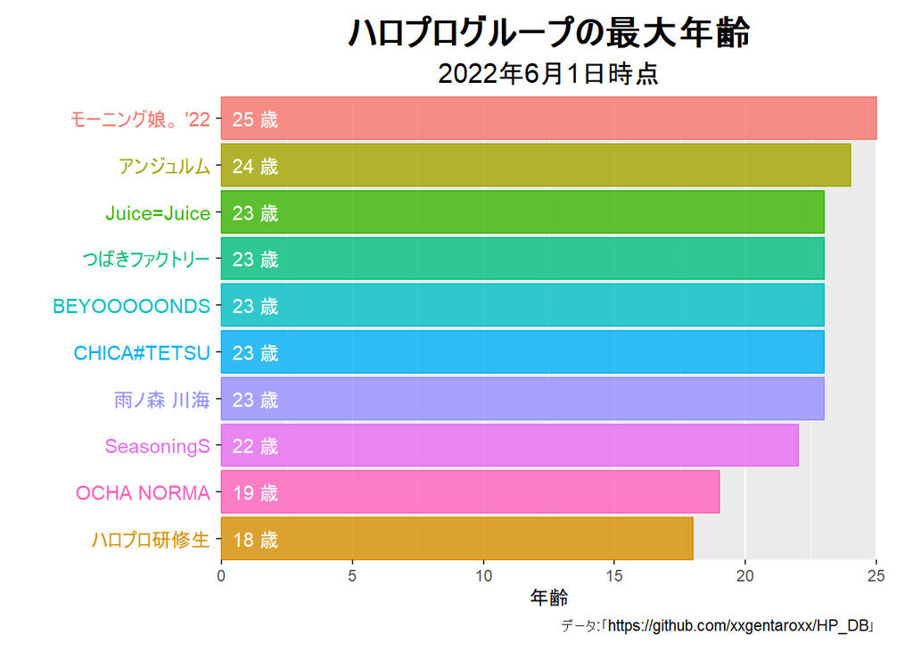

```r
# 棒グラフを作成
graph <- ggplot(mon_rank_df, aes(x = ranking, y = age, fill = groupID, color = groupID)) +
  geom_bar(stat = "identity", width = 0.9, alpha = 0.8) + # 年齢バー
  geom_text(aes(y = 0, label = paste(" ", age, "歳")), hjust = 0, color = "white") + # 年齢ラベル
  geom_text(aes(y = 0, label = paste(groupName, " ")), hjust = 1) + # グループ名ラベル
  coord_flip(clip = "off", expand = FALSE) + # 軸の入れ変え
  scale_x_reverse(breaks = 1:nrow(mon_rank_df)) + # x軸(縦軸)目盛を反転
  theme(
    axis.title.y = element_blank(), # y軸のラベル
    axis.text.y = element_blank(), # y軸の目盛ラベル
    #panel.grid.major.x = element_line(color = "grey", size = 0.1), # x軸の主目盛線
    panel.grid.major.y = element_blank(), # y軸の主目盛線
    #panel.grid.minor.x = element_line(color = "grey", size = 0.1), # x軸の補助目盛線
    panel.grid.minor.y = element_blank(), # y軸の補助目盛線
    panel.border = element_blank(), # グラフ領域の枠線
    #panel.background = element_blank(), # グラフ領域の背景
    plot.title = element_text(color = "black", face = "bold", size = 20, hjust = 0.5), # 全体のタイトル
    plot.subtitle = element_text(color = "black", size = 15, hjust = 0.5), # 全体のサブタイトル
    plot.margin = margin(t = 10, r = 20, b = 10, l = 120, unit = "pt"), # 全体の余白
    legend.position = "none" # 凡例の表示位置
  ) + # 図の体裁
  labs(
    #title = "ハロプログループの最小年齢",
    title = "ハロプログループの最大年齢",
    subtitle = paste0(
      lubridate::year(date_val), "年", lubridate::month(date_val), "月1日時点"),
    y = "年齢",
    caption = "データ:「https://github.com/xxgentaroxx/HP_DB」"
  ) # ラベル
graph
```

最小年齢か最大年齢によって、タイトル(`labs()`の`title`引数の文字列)をコメントアウトで切り替えます。

`ggsave()`で画像を保存できます。

```r
# 画像を保存
ggplot2::ggsave(
  filename = paste0("output/YearsAge_MinMax_", date_val, ".png"), plot = graph,
  width = 24, height = 18, units = "cm", dpi = 100
)
```

以上で、最小・最大年齢の推移を可視化できました。